# A1

Kurisutina

2024-09-27

### Ejercicios iniciales

**1. Con los datos de los buitres leonados**

```r
set.seed(6851)
heartbpm <- c(47.53, 48.27, 49.51, 51.09, 52.57, 54.30,
              54.25, 54.45, 57.95, 60.92, 61.91, 77.92,
              82.07, 82.95, 83.94, 86.96, 90.42, 92.93, 100.05)
metabol <- c(6.15, 6.31, 6.43, 6.78, 6.86, 6.90, 7.37, 7.41,
             8.24, 9.22, 8.16, 12.61, 15.26, 13.09, 14.59,
             17.35, 18.57, 19.00, 20.70)

vulture <- data.frame(heartbpm, metabol)
rm(heartbpm, metabol)
attach(vulture)
```

**a)Dibujar la nube de puntos con la instrucción plot().**

gráfico de dispersión

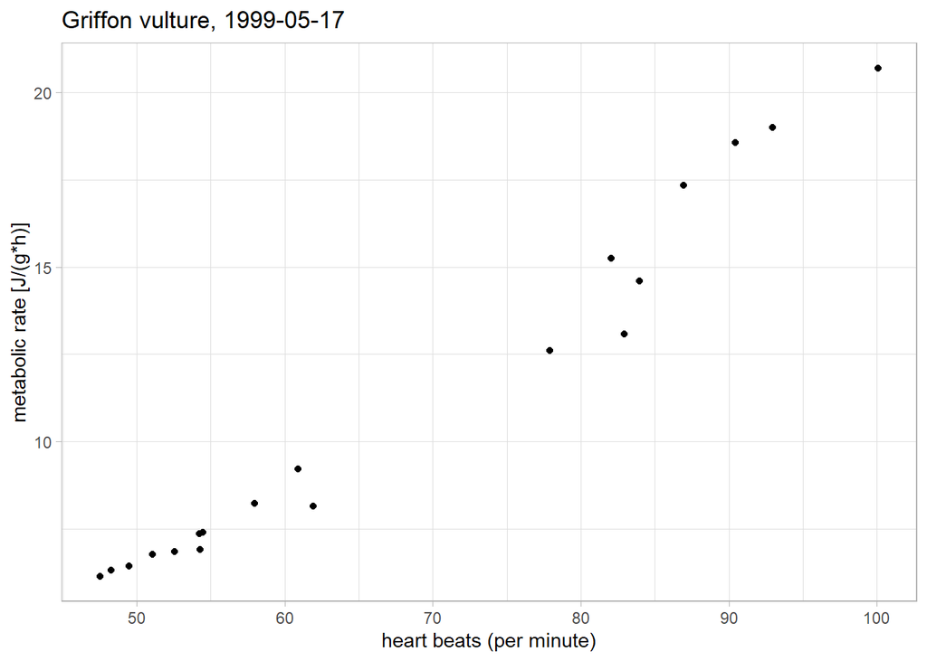

```r
library(ggplot2)
p <- ggplot(vulture, aes(x=heartbpm, y=metabol)) +
  geom_point() + labs(x = "heart beats (per minute)",
                      y = "metabolic rate [J/(g*h)]",
                      title = "Griffon vulture, 1999-05-17") +
  theme_light()
p
```

```r
p1 <- as.numeric(vulture[4,])
p2 <- as.numeric(vulture[16,])
dif <- p2 - p1
m <- dif[2]/dif[1]
b <- p1[2] - m * p1[1]
```

**b)Añadir la recta de regresión con la instrucción abline().**

incorporar esta recta al gráfico

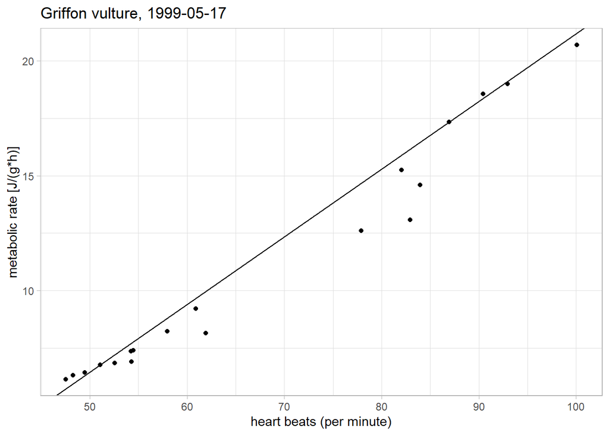

```r
p + geom_abline(intercept = b, slope = m)
```

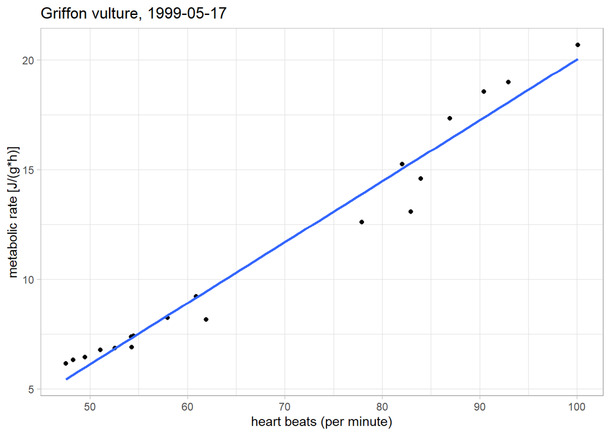

```r
p + stat_smooth(method="lm", se=FALSE)
```

# c)Dibujar el gráfico de residuos vs. valores ajustados con la función plot() aplicada al objeto lm.

**Ajustar el modelo de regresión lineal**

```r
modelo <- lm(metabol ~ heartbpm, data = vulture)
```

**Agregar la recta de regresión al gráfico**

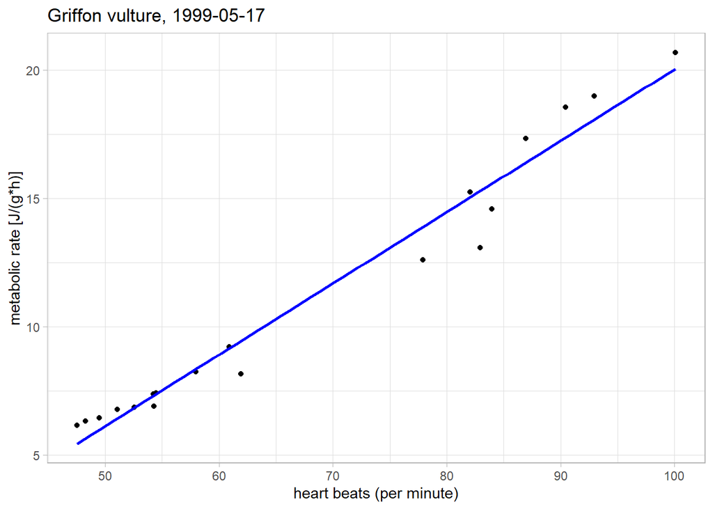

```r
p + geom_smooth(method = "lm", se = FALSE, color = "blue")
```

```r
summary(modelo)
```

```
##
## Call:
## lm(formula = metabol ~ heartbpm, data = vulture)
##
## Residuals:
##      Min       1Q   Median       3Q      Max
## -2.20684 -0.25868  0.06332  0.65532  1.19349
##
## Coefficients:
##             Estimate Std. Error t value Pr(>|t|)
## (Intercept)  -7.7967     0.8481  -9.193 5.24e-08 ***
## heartbpm      0.2784     0.0121  23.002 3.01e-14 ***
## ---
## Signif. codes:  0 '***' 0.001 '**' 0.01 '*' 0.05 '.' 0.1 ' ' 1
##
## Residual standard error: 0.9144 on 17 degrees of freedom
## Multiple R-squared:  0.9689, Adjusted R-squared:  0.967
## F-statistic: 529.1 on 1 and 17 DF,  p-value: 3.01e-14
```

**Gráfico de residuos vs. valores ajustados**

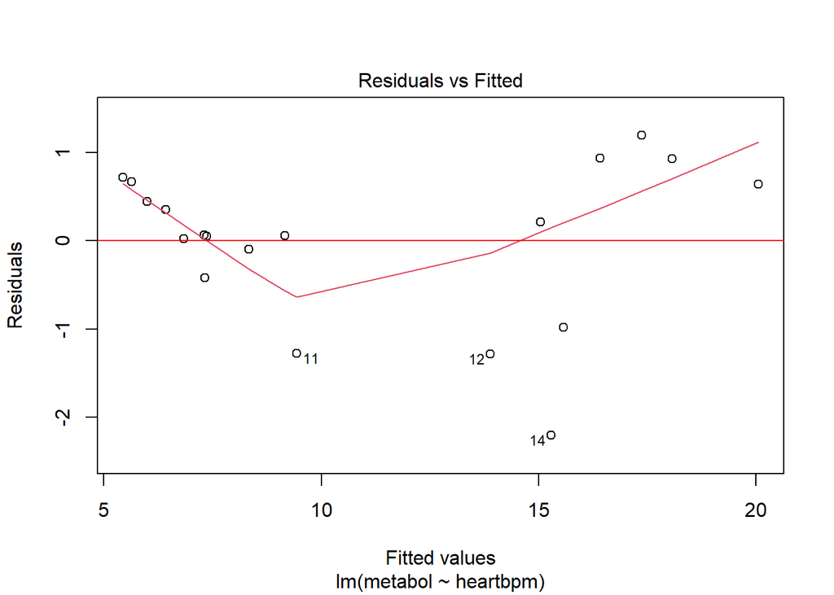

```r
plot(modelo, which = 1)

plot(modelo, which = 1)
abline(h = 0, col = "red")
```

```r
library(ggplot2)
```

**Ajustar el modelo de regresión lineal**

```r
modelo <- lm(metabol ~ heartbpm, data = vulture)
```

**Gráfico de dispersión con recta de regresión**

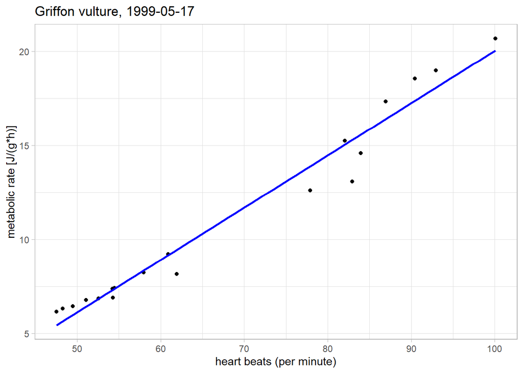

```r
p <- ggplot(vulture, aes(x = heartbpm, y = metabol)) +
  geom_point() +
  geom_smooth(method = "lm", se = FALSE, color = "blue") +
  labs(x = "heart beats (per minute)",
       y = "metabolic rate [J/(g*h)]",
       title = "Griffon vulture, 1999-05-17") +
  theme_light()
p
```

**Resumen del modelo**

```r
summary(modelo)
```

```
##
## Call:
## lm(formula = metabol ~ heartbpm, data = vulture)
##
## Residuals:
##      Min       1Q   Median       3Q      Max
## -2.20684 -0.25868  0.06332  0.65532  1.19349
##
## Coefficients:
##             Estimate Std. Error t value Pr(>|t|)
## (Intercept)  -7.7967     0.8481  -9.193 5.24e-08 ***
## heartbpm      0.2784     0.0121  23.002 3.01e-14 ***
## ---
## Signif. codes:  0 '***' 0.001 '**' 0.01 '*' 0.05 '.' 0.1 ' ' 1
##
## Residual standard error: 0.9144 on 17 degrees of freedom
## Multiple R-squared:  0.9689, Adjusted R-squared:  0.967
## F-statistic: 529.1 on 1 and 17 DF,  p-value: 3.01e-14
```

**Interpretación: el cambio promedio en la tasa metabólica por cada unidad de aumento en la frecuencia cardíaca es de 0.2784. R-squared: 0.9689, Indica la proporción de la variabilidad en la tasa metabólica que es explicada por la frecuencia cardíaca.**

**Gráfico de residuos vs. valores ajustados**

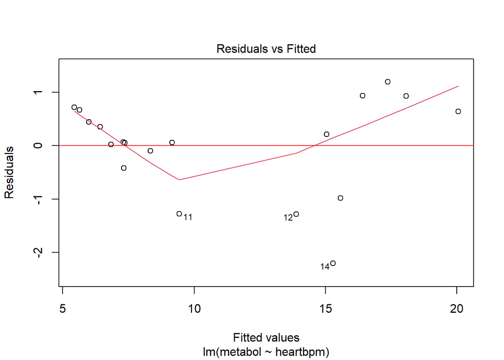

```r
plot(modelo, which = 1)
abline(h = 0, col = "red")
```

#d)Añadir al gráfico de dispersión del apartado (a) la curva de regresión parabólica. Nota: Esto último se puede hacer con la instrucción lines() o con la instrucción curve( , add = TRUE).

**Ajustar el modelo de regresión lineal y cuadrático**

```r
modelo_lineal <- lm(metabol ~ heartbpm, data = vulture)
modelo_cuadratico <- lm(metabol ~ heartbpm + I(heartbpm^2), data = vulture)
summary(modelo_cuadratico)
```

```
##
## Call:
## lm(formula = metabol ~ heartbpm + I(heartbpm^2), data = vulture)
##
## Residuals:
##      Min       1Q   Median       3Q      Max
## -1.70483 -0.44067  0.04606  0.38353  1.12852
##
## Coefficients:
##                 Estimate Std. Error t value Pr(>|t|)
## (Intercept)    5.7517186  4.1290970   1.393  0.18268
## heartbpm      -0.1263581  0.1220893  -1.035  0.31608
## I(heartbpm^2)  0.0028376  0.0008533   3.326  0.00428 **
## ---
## Signif. codes:  0 '***' 0.001 '**' 0.01 '*' 0.05 '.' 0.1 ' ' 1
##
## Residual standard error: 0.7248 on 16 degrees of freedom
## Multiple R-squared:  0.9816, Adjusted R-squared:  0.9793
## F-statistic: 426.6 on 2 and 16 DF,  p-value: 1.318e-14
```

**Predecir valores para la curva parabólica**

```r
nuevos_datos <- data.frame(heartbpm = seq(min(heartbpm), max(heartbpm), length.out = 100))
predicciones_cuadraticas <- predict(modelo_cuadratico, newdata = nuevos_datos)
```

**Gráfico de dispersión con recta de regresión lineal y curva parabólica**

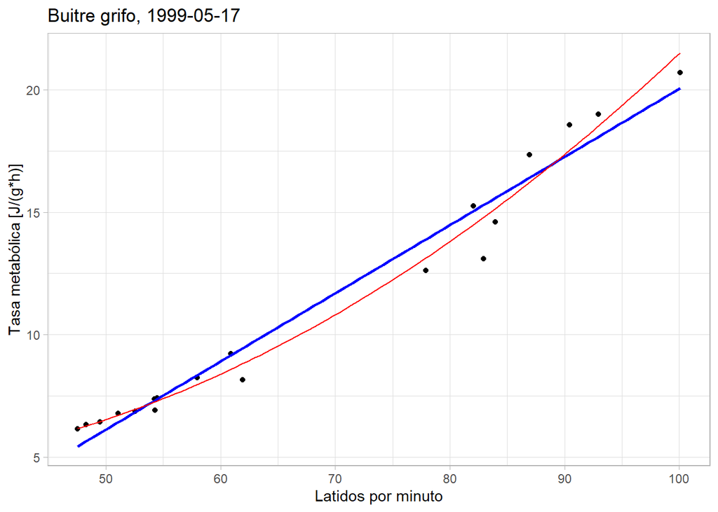

```r
M <- ggplot(vulture, aes(x = heartbpm, y = metabol)) +
  geom_point() +
  geom_smooth(method = "lm", se = FALSE, color = "blue") +  # Recta de regresión lineal
  geom_line(data = nuevos_datos, aes(x = heartbpm, y = predicciones_cuadraticas), color = "red") +  # Curva parabólica
  labs(x = "Latidos por minuto",
       y = "Tasa metabólica [J/(g*h)]",
       title = "Buitre grifo, 1999-05-17") +
  theme_light()
M
```

**Basado en los resultados, el modelo cuadrático se ajusta ligeramente mejor a los datos que el modelo lineal. Esto sugiere que la relación entre la tasa metabólica y los latidos por minuto podría no ser estrictamente lineal y que un término cuadrático puede mejorar la explicación de la variabilidad en la tasa metabólica.** **R-cuadrado ajustado: El modelo cuadrático (R² ajustado = 0.9793) tiene un R² ajustado ligeramente más alto que el modelo lineal (R² ajustado = 0.967). Esto sugiere que el modelo cuadrático explica una mayor proporción de la varianza en la variable dependiente.**

**P-valor: El término cuadrático (I(heartbpm^2)) en el modelo cuadrático tiene un p-valor de 0.00428, lo que indica que es estadísticamente significativo al nivel de significancia del 0.05. Esto sugiere que el término cuadrático es importante para explicar la relación entre las variables.**

### 2. Con los datos de la tensión arterial sistólica y la edad de los 69 pacientes que podemos encontrar

en la web de www.fisterra.com https://www.fisterra.com/formacion/metodologia-investigacion/tecnicas-regresion-regresion-lineal-simple/ calcular los coeficientes de regresión de la recta mínimo cuadrática.

Tenemos un conjunto de datos que relaciona la tensión sistólica (tensi) con la edad de un grupo de personas. Queremos encontrar la recta que mejor se ajuste a estos datos, es decir, la recta que minimice la suma de los cuadrados de las distancias entre los puntos de datos y la recta. Esta recta se conoce como recta de mínimos cuadrados y sus coeficientes (pendiente e intercepto) nos permitirán predecir la tensión sistólica para una edad dada.

```r
set.seed(3369)
fisterra <- read.csv("C:/Users/kuris/OneDrive/Escritorio/modelos de regresión/fisterra.csv", sep=";")
datos <- data.frame(fisterra)
```

**Ajustar el modelo de regresión lineal**

```r
modelo <- lm(tensis ~ Edad, data = datos)
```

**Mostrar los coeficientes**

```r
summary(modelo)
```

```
##
## Call:
## lm(formula = tensis ~ Edad, data = datos)
##
## Residuals:
##     Min      1Q  Median      3Q     Max
## -26.794  -7.024   1.960   8.190  22.634
##
## Coefficients:
##             Estimate Std. Error t value Pr(>|t|)
## (Intercept) 103.3527     4.3261   23.89   <2e-16 ***
## Edad          0.9836     0.0892   11.03   <2e-16 ***
## ---
## Signif. codes:  0 '***' 0.001 '**' 0.01 '*' 0.05 '.' 0.1 ' ' 1
##
## Residual standard error: 11.09 on 67 degrees of freedom
## Multiple R-squared:  0.6447, Adjusted R-squared:  0.6394
## F-statistic: 121.6 on 1 and 67 DF,  p-value: < 2.2e-16
```

*Interpretación: Por cada año adicional de edad, se espera que la tensión sistólica aumente en promedio 0.9836 unidades. En otras palabras, la pendiente representa la tasa de cambio de la tensión sistólica con respecto a la edad.*

**Extraer los coeficientes**

```r
intercepto <- coef(modelo)[1]
intercepto
```

```
## (Intercept)
##    103.3527
```

```r
pendiente <- coef(modelo)[2]
pendiente
```

```
##      Edad
## 0.9835585
```

**Crear un gráfico de dispersión con la recta de regresión**

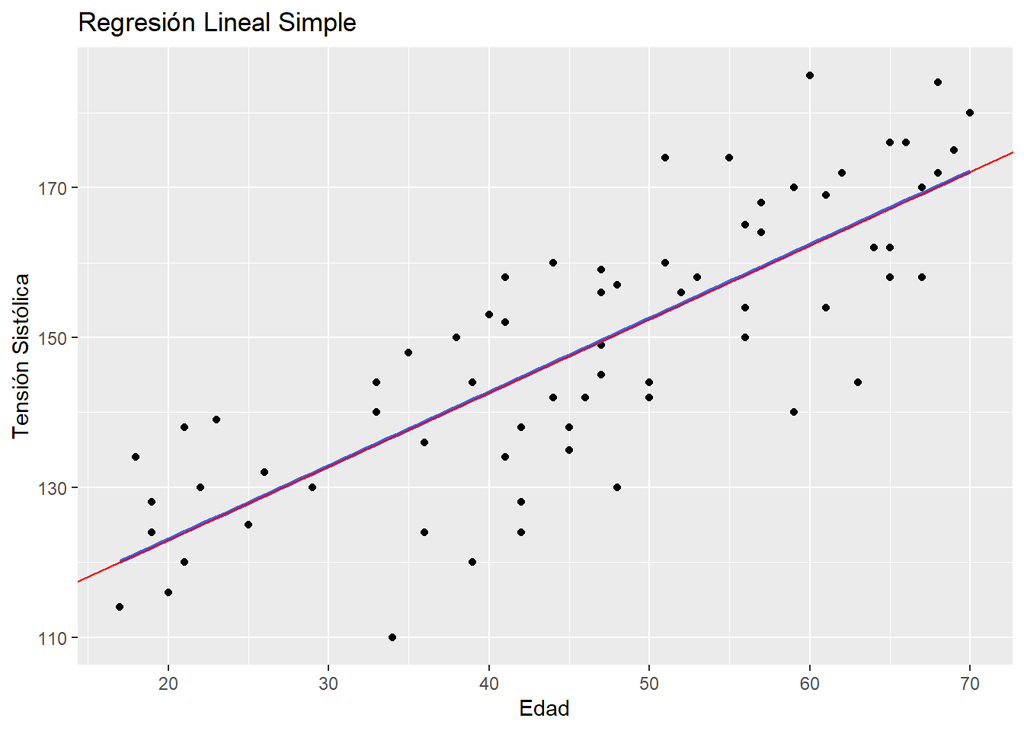

```r
library(ggplot2)
ggplot(datos, aes(x = Edad, y = tensis)) +
  geom_point() +
  geom_smooth(method = "lm", se = FALSE) +
  labs(x = "Edad", y = "Tensión Sistólica", title = "Relación entre Edad y Tensión Sistólica") +
  ggtitle("Regresión Lineal Simple") +
  geom_abline(intercept = intercepto, slope = pendiente, color = "red")
```

**Cargar las librerías necesarias**

```r
library(ggplot2)
library(ggfortify)
```

**Obtener los residuos**

```r
residuos <- residuals(modelo)
summary(residuos)
```

```
##    Min. 1st Qu.  Median    Mean 3rd Qu.    Max.
## -26.794  -7.024   1.960   0.000   8.190  22.634
```

**Gráfico de residuos vs. valores ajustados** Si los residuos se distribuyen aleatoriamente alrededor de la línea horizontal en cero, sugiere que la varianza de los errores es constante (homocedasticidad). Si hay algún patrón (por ejemplo, un embudo), podría indicar heterocedasticidad.

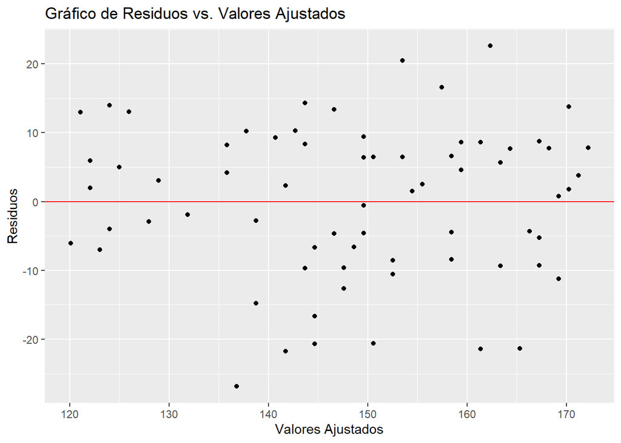

```r
ggplot(data = data.frame(ajustados = fitted(modelo), residuos),
       aes(x = ajustados, y = residuos)) +
  geom_point() +
  geom_hline(yintercept = 0, color = "red") +
  labs(x = "Valores Ajustados", y = "Residuos",
       title = "Gráfico de Residuos vs. Valores Ajustados")
```

**Gráfico de residuos vs. variable predictora (edad)**

Este gráfico te permite verificar si hay alguna relación entre los residuos y la variable predictora. Si existe una relación sistemática, podría indicar que el modelo no es adecuado.

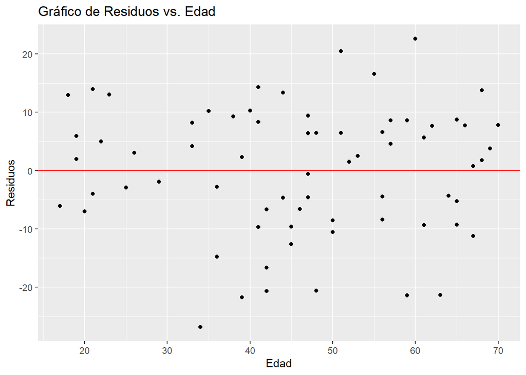

```r
ggplot(data = data.frame(Edad = datos$Edad, residuos),
       aes(x = Edad, y = residuos)) +
  geom_point() +
  geom_hline(yintercept = 0, color = "red") +
  labs(x = "Edad", y = "Residuos",
       title = "Gráfico de Residuos vs. Edad")
```

**Gráfico de normalidad de los residuos (QQ-plot)**

Este gráfico compara la distribución de los residuos con una distribución normal teórica. Si los puntos se encuentran aproximadamente sobre una línea recta, sugiere que los residuos se distribuyen normalmente.

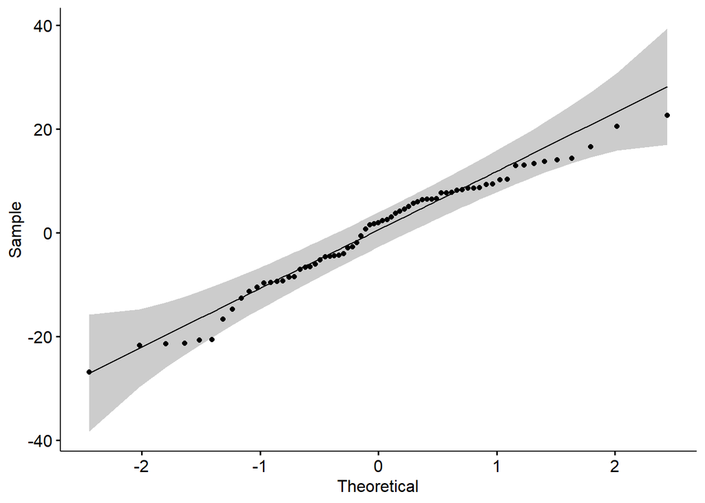

```r
library(ggplot2)
library(ggfortify)
library(ggpubr)
ggqqplot(residuos, distribution = "norm")
```

### Ejercicios del libro de Faraway

1. (Ejercicio 1 cap. 1 pág. 12)

**The dataset teengamb concerns a study of teenage gambling in Britain. Make a numerical and** **graphical summary of the data, commenting on any features that you find interesting. Limit the** **output you present to a quantity that a busy reader would find sufficient to get a basic understanding** **of the data.**

```r
library(faraway)
```

• sex: 0 = masculino, 1 = femenino • status: puntaje de estatus socioeconómico basado en la ocupación de los padres • income:: en libras por semana • verbal: puntuación verbal en palabras de 12 correctamente definidas • gamble: gasto en juegos de azar en libras por año

```r
data("teengamb")
teengamb$sex <- factor(teengamb$sex)
levels(teengamb$sex) <- c("male", "female")
summary(teengamb)
```

```
##      sex         status          income           verbal          gamble
##  male  :28   Min.   :18.00   Min.   : 0.600   Min.   : 1.00   Min.   :  0.0
##  female:19   1st Qu.:28.00   1st Qu.: 2.000   1st Qu.: 6.00   1st Qu.:  1.1
##              Median :43.00   Median : 3.250   Median : 7.00   Median :  6.0
##              Mean   :45.23   Mean   : 4.642   Mean   : 6.66   Mean   : 19.3
##              3rd Qu.:61.50   3rd Qu.: 6.210   3rd Qu.: 8.00   3rd Qu.: 19.4
##              Max.   :75.00   Max.   :15.000   Max.   :10.00   Max.   :156.0
```

```r
fit <- lm(gamble ~ sex+status+income+verbal, data=teengamb)
summary(fit)
```

```
##
## Call:
## lm(formula = gamble ~ sex + status + income + verbal, data = teengamb)
##
## Residuals:
##     Min      1Q  Median      3Q     Max
## -51.082 -11.320  -1.451   9.452  94.252
##
## Coefficients:
##              Estimate Std. Error t value Pr(>|t|)
## (Intercept)  22.55565   17.19680   1.312   0.1968
## sexfemale   -22.11833    8.21111  -2.694   0.0101 *
## status        0.05223    0.28111   0.186   0.8535
## income        4.96198    1.02539   4.839 1.79e-05 ***
## verbal       -2.95949    2.17215  -1.362   0.1803
## ---
## Signif. codes:  0 '***' 0.001 '**' 0.01 '*' 0.05 '.' 0.1 ' ' 1
##
## Residual standard error: 22.69 on 42 degrees of freedom
## Multiple R-squared:  0.5267, Adjusted R-squared:  0.4816
## F-statistic: 11.69 on 4 and 42 DF,  p-value: 1.815e-06
```

**Vamos a ver las diferencias sobre el juego y el sexo.**

Observemos un gráfico de cajas

```r
data("teengamb")
teengamb$sex <- factor(teengamb$sex)
levels(teengamb$sex) <- c("male", "female")
summary(teengamb)
```

```
##      sex         status          income           verbal          gamble
##  male  :28   Min.   :18.00   Min.   : 0.600   Min.   : 1.00   Min.   :  0.0
##  female:19   1st Qu.:28.00   1st Qu.: 2.000   1st Qu.: 6.00   1st Qu.:  1.1
##              Median :43.00   Median : 3.250   Median : 7.00   Median :  6.0
##              Mean   :45.23   Mean   : 4.642   Mean   : 6.66   Mean   : 19.3
##              3rd Qu.:61.50   3rd Qu.: 6.210   3rd Qu.: 8.00   3rd Qu.: 19.4
##              Max.   :75.00   Max.   :15.000   Max.   :10.00   Max.   :156.0
```

```r
fit <- lm(gamble ~ sex+status+income+verbal, data=teengamb)
summary(fit)
```

```
##
## Call:
## lm(formula = gamble ~ sex + status + income + verbal, data = teengamb)
##
## Residuals:
##     Min      1Q  Median      3Q     Max
## -51.082 -11.320  -1.451   9.452  94.252
##
## Coefficients:
##              Estimate Std. Error t value Pr(>|t|)
## (Intercept)  22.55565   17.19680   1.312   0.1968
## sexfemale   -22.11833    8.21111  -2.694   0.0101 *
## status        0.05223    0.28111   0.186   0.8535
## income        4.96198    1.02539   4.839 1.79e-05 ***
## verbal       -2.95949    2.17215  -1.362   0.1803
## ---
## Signif. codes:  0 '***' 0.001 '**' 0.01 '*' 0.05 '.' 0.1 ' ' 1
##
## Residual standard error: 22.69 on 42 degrees of freedom
## Multiple R-squared:  0.5267, Adjusted R-squared:  0.4816
## F-statistic: 11.69 on 4 and 42 DF,  p-value: 1.815e-06
```

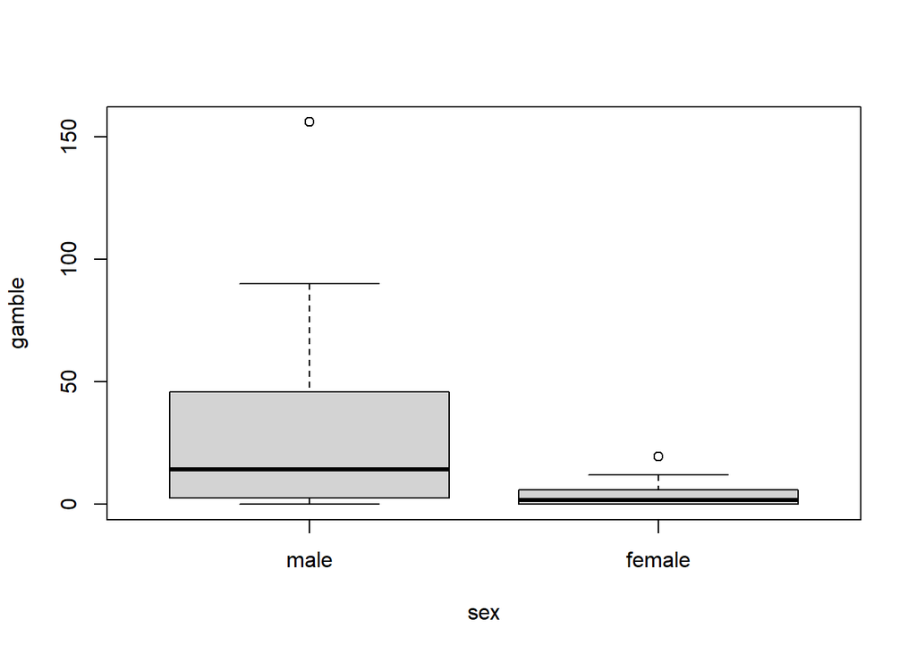

```r
plot(gamble ~ sex, data=teengamb)
```

**En general, el nivel medio de gasto en juegos de azar de los hombres es mucho mayor que el de las mujeres.**

**El gasto en juego de los hombres es mayor que la variabilidad del de las mujeres (comparando** **la longitud de dos cajas).**

**resumen detallado estadísticas para diferentes géneros**

```r
MaleGamb <- teengamb$gamble[teengamb$sex=="male"]
FemaleGamb <- teengamb$gamble[teengamb$sex=="female"]


summary(MaleGamb)
```

```
##    Min. 1st Qu.  Median    Mean 3rd Qu.    Max.
##   0.000   2.775  14.250  29.775  42.175 156.000
```

```r
summary(FemaleGamb)
```

```
##    Min. 1st Qu.  Median    Mean 3rd Qu.    Max.
##   0.000   0.100   1.700   3.866   6.000  19.600
```

**La mediana de los hombres es de aprox. 8 veces mayor que la hembra y la varianza.** **de macho es aprox. 53 veces mayor que la femenina, lo que indica nuestra observación desde el** **diagrama de caja.**

Ajuste un modelo de regresión lineal simple con el gasto en grabling como variable dependiente y los ingresos como variable independiente.

```r
fit <- lm(gamble ~ income, data=teengamb)
summary(fit)
```

```
##
## Call:
## lm(formula = gamble ~ income, data = teengamb)
##
## Residuals:
##     Min      1Q  Median      3Q     Max
## -46.020 -11.874  -3.757  11.934 107.120
##
## Coefficients:
##             Estimate Std. Error t value Pr(>|t|)
## (Intercept)   -6.325      6.030  -1.049      0.3
## income         5.520      1.036   5.330 3.05e-06 ***
## ---
## Signif. codes:  0 '***' 0.001 '**' 0.01 '*' 0.05 '.' 0.1 ' ' 1
##
## Residual standard error: 24.95 on 45 degrees of freedom
## Multiple R-squared:  0.387,  Adjusted R-squared:  0.3734
## F-statistic: 28.41 on 1 and 45 DF,  p-value: 3.045e-06
```

**Resultados: βˆ0 = −6.325 and βˆ1 = 5.520** **En promedio, el gasto en juegos de azar variará (aumentará o disminuirá)** **5.520 libras por año cuando el ingreso del hogar varía (aumenta o disminuye) 1 libra por** **semana.** **El modelo de regresión sugiere que existe una relación lineal positiva entre los ingresos del hogar y los gastos en juegos de azar. Por cada libra** **adicional de ingresos semanales en el hogar, podemos esperar un aumento promedio de 5,520 libras en gastos de juego por año.**

**predecir el valor medio de gasto**

```r
apuesta = -6.325 + 5.520*(2)
apuesta
```

```
## [1] 4.715
```

**residuos de todas las observaciones.**

```r
residuals(fit)
```

```
##           1           2           3           4           5           6
##  -4.7164115  -7.4766542  -4.7164115 -25.0188380  14.8835885 -12.7315249
##           7           8           9          10          11          12
## -22.5881100 -22.5169565  -3.0164115 -26.6983527 -10.1368968 -14.4977461
##          13          14          15          16          17          18
##  -4.6205086  -1.1164115  -7.8368968   1.4438311 -46.0200512 -40.4802938
##          19          20          21          22          23          24
##  -3.7573821 -12.9971395  -9.2368968  -6.2766542 -12.8971395 107.1197062
##          25          26          27          28          29          30
##   8.9414047   0.1438311  -9.2068809   3.8040737   3.6122679 -14.4381100
##          31          32          33          34          35          36
##  28.0787356  20.8811620  13.5172798  -1.7164115  12.1438311  51.4823753
##          37          38          39          40          41          42
##  31.0233458  19.3606768 -42.8802938  22.4917826   2.1835885  -6.7827202
##          43          44          45          46          47
##   3.0631032 -11.0170181  17.0533617  12.4438311  11.7233458
```

**Calcule la media y la mediana de los residuos**

```r
resid <- residuals(fit)
mean(resid)
```

```
## [1] -7.71103e-16
```

```r
median(resid)
```

```
## [1] -3.757382
```

**Calcule el error cuadrático medio utilizando residuos.**

```r
EC <- sum(resid^2)/(47-2)
EC
```

```
## [1] 622.4131
```

**resultados: la regresión, encontramos que el valor p es 3,05 × 10−6,** **significa que la variación de la variable de juego puede explicarse linealmente por la variable de ingreso.**

# 2. (Ejercicio 2 pág. 12)

The dataset uswages is drawn as a sample from the Current Population Survey in 1988. Make a numerical and graphical summary of the data as in the previous question.

```r
set.seed(7778)
data("uswages")#Loading the entire uswages dataset#

summary(uswages)
```

```
##       wage              educ           exper            race
##  Min.   :  50.39   Min.   : 0.00   Min.   :-2.00   Min.   :0.000
##  1st Qu.: 308.64   1st Qu.:12.00   1st Qu.: 8.00   1st Qu.:0.000
##  Median : 522.32   Median :12.00   Median :15.00   Median :0.000
##  Mean   : 608.12   Mean   :13.11   Mean   :18.41   Mean   :0.078
##  3rd Qu.: 783.48   3rd Qu.:16.00   3rd Qu.:27.00   3rd Qu.:0.000
##  Max.   :7716.05   Max.   :18.00   Max.   :59.00   Max.   :1.000
##       smsa             ne              mw               so
##  Min.   :0.000   Min.   :0.000   Min.   :0.0000   Min.   :0.0000
##  1st Qu.:1.000   1st Qu.:0.000   1st Qu.:0.0000   1st Qu.:0.0000
##  Median :1.000   Median :0.000   Median :0.0000   Median :0.0000
##  Mean   :0.756   Mean   :0.229   Mean   :0.2485   Mean   :0.3125
##  3rd Qu.:1.000   3rd Qu.:0.000   3rd Qu.:0.0000   3rd Qu.:1.0000
##  Max.   :1.000   Max.   :1.000   Max.   :1.0000   Max.   :1.0000
##        we             pt
##  Min.   :0.00   Min.   :0.0000
##  1st Qu.:0.00   1st Qu.:0.0000
##  Median :0.00   Median :0.0000
##  Mean   :0.21   Mean   :0.0925
##  3rd Qu.:0.00   3rd Qu.:0.0000
##  Max.   :1.00   Max.   :1.0000
```

```r
dplyr::glimpse(uswages)
```

```
## Rows: 2,000
## Columns: 10
## $ wage  <dbl> 771.60, 617.28, 957.83, 617.28, 902.18, 299.15, 541.31, 148.39, …
## $ educ  <int> 18, 15, 16, 12, 14, 12, 16, 16, 12, 12, 9, 14, 17, 14, 14, 10, 1…
## $ exper <int> 18, 20, 9, 24, 12, 33, 42, 0, 36, 37, 20, 29, 16, 21, 11, 10, 8,…
## $ race  <int> 0, 0, 0, 0, 0, 0, 0, 0, 0, 0, 1, 0, 0, 0, 0, 0, 0, 0, 0, 0, 0, 0…
## $ smsa  <int> 1, 1, 1, 1, 1, 1, 1, 1, 1, 0, 1, 1, 0, 1, 0, 1, 0, 1, 1, 1, 0, 1…
## $ ne    <int> 1, 0, 0, 1, 0, 0, 0, 0, 0, 0, 0, 0, 1, 0, 0, 0, 0, 0, 1, 0, 0, 0…
## $ mw    <int> 0, 0, 0, 0, 1, 0, 0, 1, 0, 1, 0, 0, 0, 0, 1, 0, 0, 0, 0, 0, 0, 0…
## $ so    <int> 0, 0, 1, 0, 0, 0, 1, 0, 0, 0, 1, 1, 0, 0, 0, 0, 1, 1, 0, 1, 1, 1…
## $ we    <int> 0, 1, 0, 0, 0, 1, 0, 0, 1, 0, 0, 0, 0, 1, 0, 1, 0, 0, 0, 0, 0, 0…
## $ pt    <int> 0, 0, 0, 0, 0, 0, 1, 1, 1, 0, 1, 0, 0, 1, 0, 0, 0, 0, 0, 0, 0, 0…
```

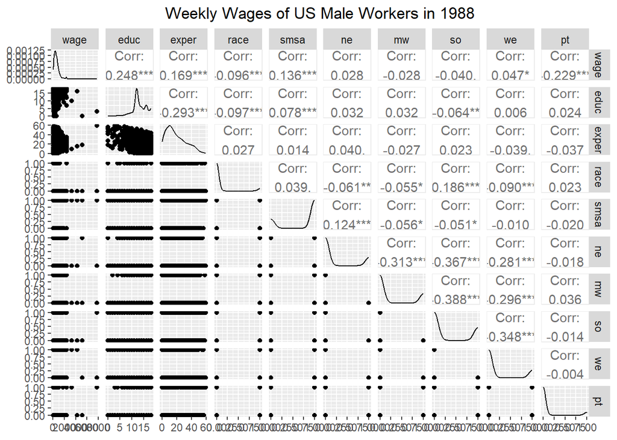

```r
uswages$exper[uswages$exper < 0] <- NA

if (require(GGally)){             #https://rpubs.com/sadjei65320/754802
  uswages %>%
    ggpairs() + ggtitle("Weekly Wages of US Male Workers in 1988") + theme(plot.title = element_text(hjust = 0.5))
}
```

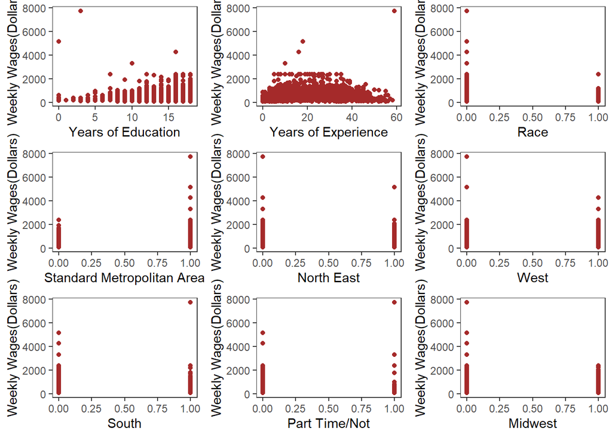

```r
#https://rpubs.com/sadjei65320/754802
A=ggplot(uswages)+geom_point(aes(x=educ,y=wage),color="brown")+theme_bw()+xlab("Years of Education")+ylab("Weekly Wages(Dollars)")+theme(panel.grid = element_blank())
B=ggplot(uswages)+geom_point(aes(x=exper,y=wage),color="brown")+theme_bw()+xlab("Years of Experience")+ylab("Weekly Wages(Dollars)")+theme(panel.grid = element_blank())
C=ggplot(uswages)+geom_point(aes(x=race,y=wage),color="brown")+theme_bw()+xlab("Race")+ylab("Weekly Wages(Dollars)")+theme(panel.grid = element_blank())
D=ggplot(uswages)+geom_point(aes(x=smsa,y=wage),color="brown")+theme_bw()+xlab("Standard Metropolitan Area")+ylab("Weekly Wages(Dollars)")+theme(panel.grid = element_blank())
E=ggplot(uswages)+geom_point(aes(x=ne,y=wage),color="brown")+theme_bw()+xlab("North East")+ylab("Weekly Wages(Dollars)")+theme(panel.grid = element_blank())
G=ggplot(uswages)+geom_point(aes(x=we,y=wage),color="brown")+theme_bw()+xlab("West")+ylab("Weekly Wages(Dollars)")+theme(panel.grid = element_blank())
H=ggplot(uswages)+geom_point(aes(x=so,y=wage),color="brown")+theme_bw()+xlab("South")+ylab("Weekly Wages(Dollars)")+theme(panel.grid = element_blank())
I=ggplot(uswages)+geom_point(aes(x=pt,y=wage),color="brown")+theme_bw()+xlab("Part Time/Not")+ylab("Weekly Wages(Dollars)")+theme(panel.grid = element_blank())
J=ggplot(uswages)+geom_point(aes(x=mw,y=wage),color="brown")+theme_bw()+xlab("Midwest")+ylab("Weekly Wages(Dollars)")+theme(panel.grid = element_blank())
library(gridExtra)
grid.arrange(A,B,C,D,E,G,H,I,J,nrow =3,ncol = 3)
```

**Las personas con muchos años de educación tienen salarios semanales altos a pesar de que tienen menos años de experiencia.**

Revisando modelos

```r
Full_model=lm(wage ~ educ + exper + race + smsa + ne + mw + so + we + pt,data=uswages)
Stepwise_model=step(Full_model,direction="both",test="F")
```

```
## Start:  AIC=23700.79
## wage ~ educ + exper + race + smsa + ne + mw + so + we + pt
##
##
## Step:  AIC=23700.79
## wage ~ educ + exper + race + smsa + ne + mw + so + pt
##
##         Df Sum of Sq       RSS   AIC  F value    Pr(>F)
## <none>               333222495 23701
## - ne     1    487686 333710181 23702   2.8656 0.0906498 .
## - so     1    487788 333710282 23702   2.8662 0.0906163 .
## - mw     1    660523 333883018 23703   3.8812 0.0489703 *
## - race   1   2023402 335245897 23711  11.8894 0.0005765 ***
## - smsa   1   4824448 338046942 23727  28.3482  1.13e-07 ***
## - pt     1  16027481 349249975 23791  94.1767 < 2.2e-16 ***
## - exper  1  25195227 358417722 23842 148.0460 < 2.2e-16 ***
## - educ   1  38903177 372125672 23916 228.5933 < 2.2e-16 ***
## ---
## Signif. codes:  0 '***' 0.001 '**' 0.01 '*' 0.05 '.' 0.1 ' ' 1
```

```r
Select_model=lm(wage~educ + exper + smsa + race + mw + pt, data=uswages)
summary(Select_model)
```

```
##
## Call:
## lm(formula = wage ~ educ + exper + smsa + race + mw + pt, data = uswages)
##
## Residuals:
##    Min     1Q Median     3Q    Max
## -891.3 -214.3  -56.3  130.3 7494.4
##
## Coefficients:
##              Estimate Std. Error t value Pr(>|t|)
## (Intercept) -241.4773    51.3289  -4.705 2.72e-06 ***
## educ          49.2583     3.2592  15.114  < 2e-16 ***
## exper          8.9001     0.7362  12.089  < 2e-16 ***
## smsa         115.6690    21.7615   5.315 1.19e-07 ***
## race        -128.8146    34.7941  -3.702  0.00022 ***
## mw           -21.4713    21.6338  -0.992  0.32108
## pt          -325.4332    33.6337  -9.676  < 2e-16 ***
## ---
## Signif. codes:  0 '***' 0.001 '**' 0.01 '*' 0.05 '.' 0.1 ' ' 1
##
## Residual standard error: 412.7 on 1960 degrees of freedom
##   (33 observations deleted due to missingness)
## Multiple R-squared:  0.1926, Adjusted R-squared:  0.1901
## F-statistic: 77.93 on 6 and 1960 DF,  p-value: < 2.2e-16
```

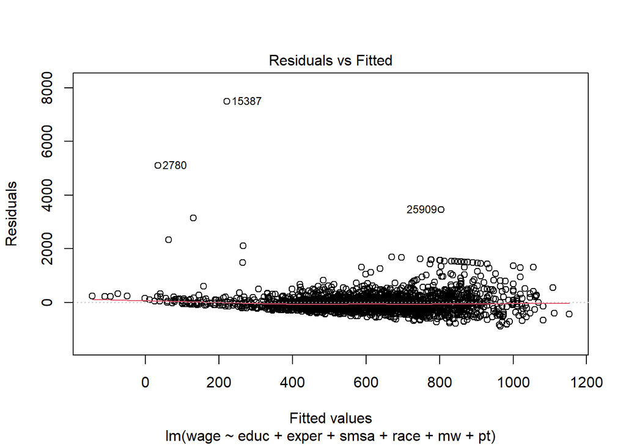

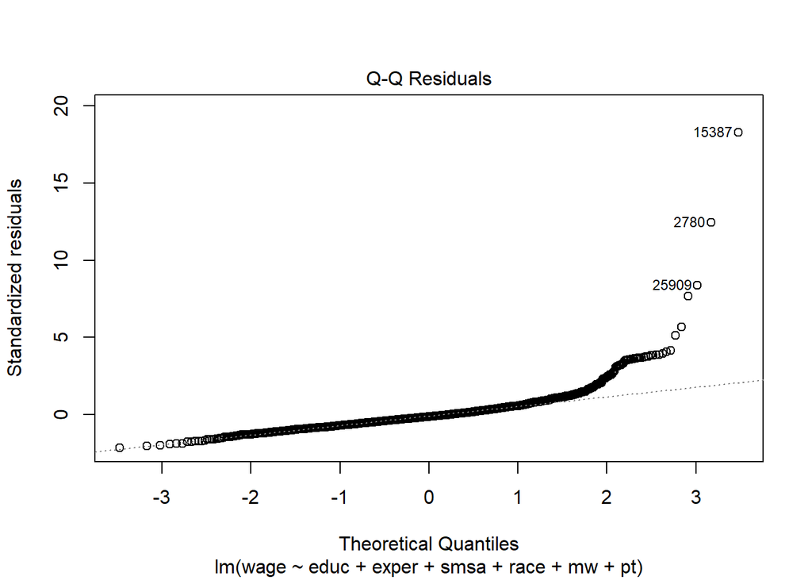

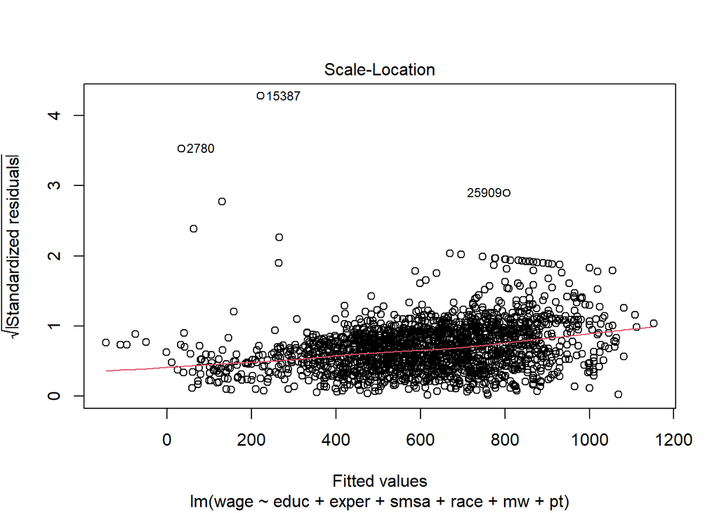

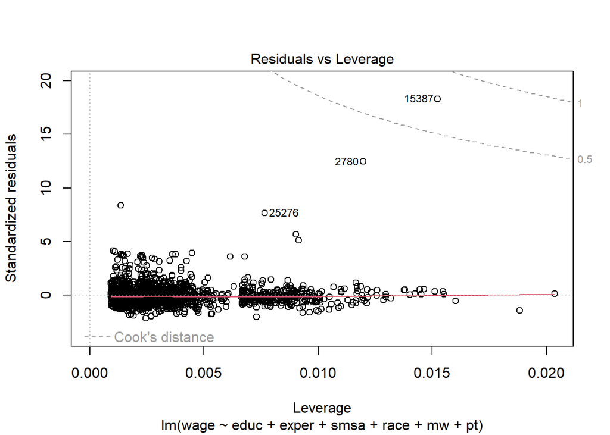

```r
plot(Select_model)
```

La regresión de los salarios semanales en función de los años de experiencia y educación.

```r
# Modelo de regresión lineal múltiple con salario como variable dependiente y educación y experiencia como predictores
modelo <- lm(wage ~ educ + exper, data = uswages)

# Resumen del modelo
summary(modelo)
```

```
##
## Call:
## lm(formula = wage ~ educ + exper, data = uswages)
##
## Residuals:
##     Min      1Q  Median      3Q     Max
## -1014.7  -235.2   -52.1   150.1  7249.2
##
## Coefficients:
##              Estimate Std. Error t value Pr(>|t|)
## (Intercept) -239.1146    50.7111  -4.715 2.58e-06 ***
## educ          51.8654     3.3423  15.518  < 2e-16 ***
## exper          9.3287     0.7602  12.271  < 2e-16 ***
## ---
## Signif. codes:  0 '***' 0.001 '**' 0.01 '*' 0.05 '.' 0.1 ' ' 1
##
## Residual standard error: 426.8 on 1964 degrees of freedom
##   (33 observations deleted due to missingness)
## Multiple R-squared:  0.1348, Adjusted R-squared:  0.1339
## F-statistic:   153 on 2 and 1964 DF,  p-value: < 2.2e-16
```